# Tutorial 5 - Consumption, investment and equilibrium output - Solutions

Theo Arvanitopoulos

# Exercises

## Exercise 1

Consider the following data from a simple economy.

| Income (Y) | 75 | 100 | 125 | 150 | 175 |
| --- | --- | --- | --- | --- | --- |
| Consumption(C) | 90 | 110 | 130 | 150 | 170 |

a. Calculate the marginal propensity to consume.

b. How much is autonomous consumption (if the consumption function is linear)?

**Answer:**

a. Note that every time $Y$ goes up by $25$, $C$ goes up by $20$. Therefore, the marginal propensity to consume is $\Delta C/\Delta Y = 20/25 = 0.8$

b. The consumption function is of the form $C = a + 0.8Y$. Pick any pair of income and consumption to calculate the value of “a”. Autonomous consumption $= 30$

## Exercise 2

The following table illustrates the consumption and savings pattern of a household. Assume that the household has £50,000 in real assets which they may draw down if necessary.

| Consumption | Savings | Income | Net Taxes |
| --- | --- | --- | --- |
| 2,000 | -2,000 | 0 | 0 |
| 8,375 | 125 | 10,000 | 1,500 |
| 14,750 | 2,250 | 20,000 | 3,000 |
| 21,125 | 4,375 | 30,000 | 4,500 |
| 27,500 | 6,500 | 40,000 | 6,000 |

a. Graph the consumption function of this household.

b. Calculate the MPC and the MPS.

c. In algebraic form, derive the consumption and saving functions for this household

d. Calculate the household’s APC at each level of disposable income. Does the APC increase or decrease as disposable income increase? Why is this so?

**Answer:**

Let disposable income be $Y_D=Y-T$, where $T$ denotes net taxes. The first two observations give $\Delta Y_D=8{,}500$ and $\Delta C=6{,}375$.

a. Plot $C$ vertically against $Y_D$ horizontally. The straight line is $C=2{,}000+0.75Y_D$: it passes through $(0,2{,}000)$ and $(34{,}000,27{,}500)$.

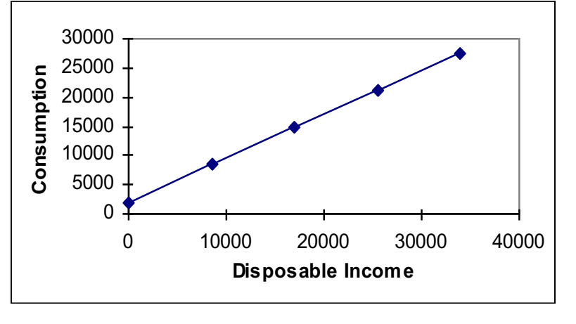

Consumption function

b. $MPC=\Delta C/\Delta Y_D=6{,}375/8{,}500=0.75$. Similarly $MPS=2{,}125/8{,}500=0.25=1-MPC$.

c. Since $S=Y_D-C$:

$$C=2{,}000+0.75Y_D,\qquad
S=-2{,}000+0.25Y_D.$$

d. Average propensity to consume is $APC=C/Y_D$.

| Disposable income (£) | Consumption (£) | APC |
| --- | --- | --- |
| 0 | 2,000 | Undefined |
| 8,500 | 8,375 | 0.9853 |
| 17,000 | 14,750 | 0.8676 |
| 25,500 | 21,125 | 0.8284 |
| 34,000 | 27,500 | 0.8088 |

For positive disposable income, $APC=2{,}000/Y_D+0.75$ falls as income rises. Positive autonomous consumption means APC exceeds MPC; consuming more than current income does not imply MPC exceeds one.

## Exercise 3

Consider a simple economy where there are no exports and imports and no government. The consumption function is given by $C = 250 + 0.5Y$ and investment is $650$.

a. Calculate the equilibrium level of income.

b. What is the value of the autonomous spending multiplier?

c. Suppose investment falls by $100$. What will be the resulting change in equilibrium income?

**Answer:**

a. In this two-sector economy, equilibrium requires output to equal planned expenditure:

$$Y=250+0.5Y+650\quad\Rightarrow\quad
Y^*=\frac{900}{1-0.5}=1{,}800.$$

b. The autonomous-spending multiplier is $k=1/(1-MPC)=1/(1-0.5)=2$.

c. With $\Delta I=-100$, $\Delta Y^*=k\Delta I=2(-100)=-200$. New investment is $550$ and new equilibrium output is $1{,}600$, which also follows from $(250+550)/(1-0.5)$.

## Exercise 4

Consider a closed economy without government, with fixed prices, in which consumers spend £120 billion on goods and services regardless of income; the marginal propensity to consume is 0.8. Planned investment is initially £400 billion at every level of income.

a. Write down the equation for planned aggregate expenditure.

b. Write down the equation describing equilibrium.

c. Compute the equilibrium level of output.

Assume that there are two firms in the economy and that:

Firm 1’s costs and expected returns from six different investment proposals are as follows:

| Project | A | B | C | D | E | F |
| --- | --- | --- | --- | --- | --- | --- |
| Cost (billions) | 100 | 50 | 150 | 80 | 40 | 60 |
| Annual Expected Rate of Return | 14% | 18% | 12% | 10% | 16% | 20% |

Firm 2’s costs and returns are as follows:

| Project | A | B | C | D | E | F |
| --- | --- | --- | --- | --- | --- | --- |
| Cost (billions) | 50 | 350 | 500 | 300 | 250 | 300 |
| Annual Expected Rate of Return | 5% | 12% | 10% | 7% | 15% | 8% |

d. Draw the aggregate investment schedule and find the equilibrium rate of interest compatible with investment demand of £400 billion.

e. What is the equilibrium level of income if the real interest rate is 18%?

f. Is there a recessionary or inflationary gap now? How much?

g. What would you expect to happen to the equilibrium level of income if investors became pessimistic about the direction of the economy in the upcoming year?

**Answer:**

All monetary amounts are £ billions. The initial model treats investment as planned spending and has no government or foreign trade. The later project schedules explain which investment amounts firms choose at different interest rates.

a. Planned aggregate expenditure is $AE=C+I^P=120+0.8Y+400=520+0.8Y$.

b. Equilibrium requires $Y=AE$, so $Y=520+0.8Y$.

c. $0.2Y=520$, giving $Y^*=2{,}600$. This is equilibrium output; the question does not establish that it is full-employment output.

d. Assume all projects are independent and firms undertake a project when its expected return is at least the interest rate, including equality. This convention matters at the listed return thresholds.

| Expected return | Project | Cost | Cumulative investment as the interest rate falls |
| --- | --- | --- | --- |
| 20% | Firm 1, F | 60 | 60 |
| 18% | Firm 1, B | 50 | 110 |
| 16% | Firm 1, E | 40 | 150 |
| 15% | Firm 2, E | 250 | 400 |
| 14% | Firm 1, A | 100 | 500 |
| 12% | Firm 1, C and Firm 2, B | $150+350=500$ | 1,000 |
| 10% | Firm 1, D and Firm 2, C | $80+500=580$ | 1,580 |
| 8% | Firm 2, F | 300 | 1,880 |
| 7% | Firm 2, D | 300 | 2,180 |
| 5% | Firm 2, A | 50 | 2,230 |

Draw a downward step schedule with planned investment horizontally and the interest rate vertically. At 15%, Firm 1 chooses F, B and E ($60+50+40=150$), and Firm 2 chooses E ($250$), so total investment is $400$. More generally, any rate strictly above 14% and at most 15% produces $I^P=400$ under this convention. A unique market-clearing rate would require a financing-supply condition; 15% is a compatible rate, not uniquely determined by the table.

e. At 18%, Firm 1 chooses F and B and Firm 2 chooses no projects, so $I^P=60+50=110$. Thus

$$Y^*=\frac{120+110}{1-0.8}=1{,}150.$$

Equilibrium output falls by $2{,}600-1{,}150=1{,}450$ relative to the initial equilibrium.

f. Full-employment output $Y_F$ is not specified, so a recessionary or inflationary gap cannot be identified unconditionally. **If the initial equilibrium is assumed to be full employment**, $Y_F=2{,}600$ and the new recessionary output gap is $2{,}600-1{,}150=1{,}450$. The corresponding shortfall in autonomous expenditure is $1{,}450/5=290$.

g. Pessimism reduces expected project returns and shifts investment demand left. At a given interest rate, fewer projects are undertaken; lower planned investment reduces equilibrium income through the multiplier. With MPC 0.8, $\Delta Y^*=5\Delta I^P$.

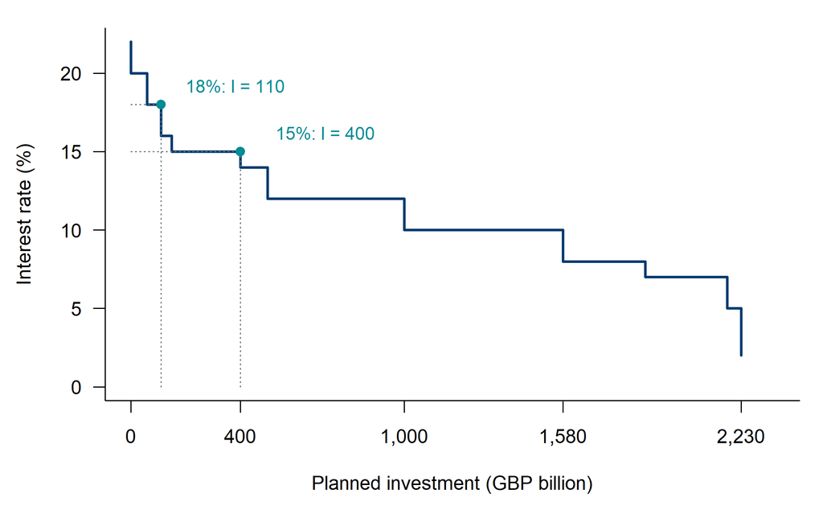

## Exercise 5

Consider a closed economy without government and with fixed prices. The consumption function is $C = 100 + 0.8Y$, and planned investment is $200$.

a. Calculate the equilibrium level of income in this economy.

b. Suppose that the full employment level of income is $2000$. Is there an inflationary or a deflationary gap?

c. By how much would autonomous spending have to change in order to move the economy to full employment equilibrium?

**Answer:**

a. $Y=100+0.8Y+200$, so $Y^*=300/(1-0.8)=1{,}500$.

b. Full-employment output is $Y_F=2{,}000$, so the economy has a recessionary (deflationary) output gap of $2{,}000-1{,}500=500$. The planned-spending shortfall at $Y_F$ is $2{,}000-[100+0.8(2{,}000)+200]=100$. Distinguish the output gap from this expenditure gap.

c. The multiplier is $k=1/(1-0.8)=5$. To raise equilibrium output by 500, autonomous expenditure must rise by $\Delta A=\Delta Y^*/k=500/5=100$.

## Exercise 6

How would you distinguish between an investment defined by an economist and an investment as defined by a stock market investor?

**Answer:**

Economic investment is spending on newly produced capital goods, residential construction, and inventory accumulation. Financial investment includes buying shares and bonds, which changes ownership of financial claims. Buying an existing share is not itself new production or GDP investment; financing raised by a firm may subsequently fund new capital spending.

# Multiple-choice questions

## MCQ 1

The MPC is the ratio of

a. extra consumption to extra disposable income.

b. extra consumption to total income.

c. total consumption to total income.

d. total consumption to extra income.

**Answer:**

A. $MPC=\Delta C/\Delta Y_D$, the change in consumption divided by the change in disposable income.

## MCQ 2

*MCQs 2–3 relate to the following table:*

| Disposable Income (£) |  | Consumption (£) |
| --- | --- | --- |
| 100 |  | 225 |
| 200 |  | 300 |
| 300 |  | 375 |
| 400 |  | 450 |
| 500 |  | 525 |
| 600 |  | 600 |

If disposable income is £400, saving is

a. - £50.

b. £0.

c. £50.

d. £100.

**Answer:**

A. At disposable income £400, consumption is £450, so $S=Y_D-C=400-450=-50$.

## MCQ 3

*Refer to the table in MCQ 2.*

The marginal propensity to save is

a. decreasing as disposable income rises.

b. equal to 0.0 when disposable income equals £ 600.

c. constant at 0.75.

d. constant at 0.25.

**Answer:**

D. Each extra £100 of disposable income raises consumption by £75 and saving by £25. Thus $MPS=25/100=0.25$; $MPC=0.75$.

## MCQ 4

Which of the following is likely to cause a shift of the consumption function?

a. A change in labour productivity.

b. A change in disposable income.

c. A change in wealth.

d. A change in GDP.

**Answer:**

C